# Assignment 8: Base R

Nandagopal Panicker

08/01/2024

### Question 1: Subsetting

#### Select the element in 10th row and 5th column in `iris` dataset

```r
data(iris)
head(iris)
```

|  | Sepal.Length | Sepal.Width | Petal.Length | Petal.Width | Species |
| --- | --- | --- | --- | --- | --- |
| 1 | 5.1 | 3.5 | 1.4 | 0.2 | setosa |
| 2 | 4.9 | 3.0 | 1.4 | 0.2 | setosa |
| 3 | 4.7 | 3.2 | 1.3 | 0.2 | setosa |
| 4 | 4.6 | 3.1 | 1.5 | 0.2 | setosa |
| 5 | 5.0 | 3.6 | 1.4 | 0.2 | setosa |
| 6 | 5.4 | 3.9 | 1.7 | 0.4 | setosa |

```r
iris[10,5] # by following the (i,j) rule of thumb.
```

```
[1] setosa
Levels: setosa versicolor virginica
```

#### Select the Species column in `iris` dataset and print the last 5 rows of that column

```r
SpeciesCol <- iris$Species
tail(SpeciesCol,5)
```

```
[1] virginica virginica virginica virginica virginica
Levels: setosa versicolor virginica
```

#### What is the average Sepal Length of flowers with Petal widths greater than 1?

```r
filtered_data <- iris[iris$Petal.Width > 1, ]
avg_sepal_len <- mean(filtered_data$Sepal.Length)

avg_sepal_len
```

```
[1] 6.325806
```

Thus, the average sepal length for flowers with petal widths greater than 1 is 6.325806.

### Question 2: For Loops

#### Write a `for` loop that iterates over the numbers 1 to 10. If the number less than 5 print the multiple of 3 (multiply the number by 3), and if the number is greater than or equal to 5 print the multiple of 2 (multiply the number by 2).

```r
for (i in 1:10) {
  if (i<5) {
    print(i*3)
  } else {
    print(i*2)
  }
}
```

```
[1] 3
[1] 6
[1] 9
[1] 12
[1] 10
[1] 12
[1] 14
[1] 16
[1] 18
[1] 20
```

### Question 3: While loops

#### Write a `while` loop that prints out random normal numbers with mean equal 1 and standard deviation 2 (use rnorm()) but stops (breaks) if you get a number bigger than 3. Do not change the value inside set.seeed.

```r
set.seed(184)
n <- 0

while (n<3) {
  n <- rnorm(1, mean = 1, sd = 2)
  print(n)

  if(n>3) {
    break
  }
}
```

```
[1] 0.1167419
[1] 1.588951
[1] 2.436941
[1] 0.932507
[1] 2.408507
[1] -1.206123
[1] -1.158457
[1] 4.96388
```

### Question 4: for loops in data tables

#### Use a nested for loop that produces the following data frame. Name the dataframe `Counting` and the variables (columns) V1, V2, V3, and V4. (There are 3 loops).

Hint: First identify the pattern(s) in the table before you create the for loop.

| V1 | V2 | V3 | V4 |
| --- | --- | --- | --- |
| 1 | 2 | 3 | 4 |
| 2 | 3 | 4 | 5 |
| 3 | 4 | 5 | 6 |

```r
Counting <- matrix(data = NA, nrow= 3, ncol =4)

for (i in 1:3) {
  for (j in 1:4) {
    Counting[i,j] = i+j - 1

  }
}

Counting
```

```
     [,1] [,2] [,3] [,4]
[1,]    1    2    3    4
[2,]    2    3    4    5
[3,]    3    4    5    6
```

### Question 5: user defined functions

#### 5A) Complete the following user define function to generate `n` random normal numbers with a given mean and standard deviation and plot a histogram of it. Do not change the seed number in set.seed. You can use the function `hist` to plot the histogram.

##### 5B) Then call the function to generate 1000 random normal numbers with mean 0 and standard deviation 1 and plot a histogram of it.

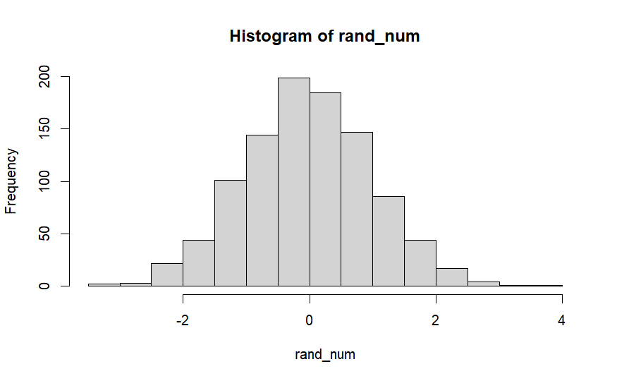

```r
set.seed(184)
plotNormal <- function(repititions, mean, sd){
  rand_num <- rnorm(repititions, mean, sd)
  hist(rand_num)
}

plotNormal(1000, 0, 1)
```

##### Extra Credit:

Repeat parts 5A and 5B, and add

1. A title that say “Histogram from a Normal(`mean`, `sd`) Distribution”, but the user given values of `mean` and `sd`.
2. an argument to change the color of the histogram.

Call the function to generate 1000 random normal numbers with mean 0 and standard deviation 1 and plot a histogram. Make the bins blue.

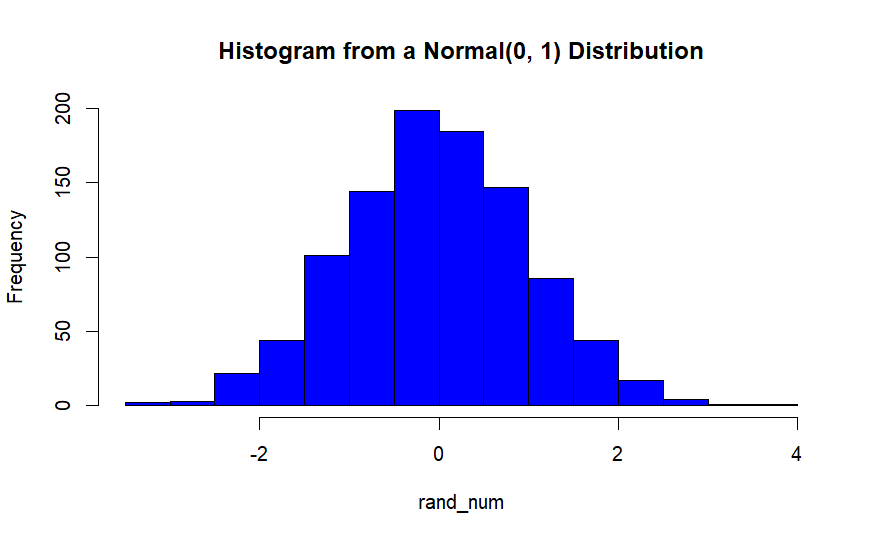

```r
set.seed(184)
plotNormal <- function(repitions, mean, sd, color) {
  rand_num <- rnorm(repitions, mean, sd)
  hist(rand_num,
       main = paste("Histogram from a Normal(", mean, ", ", sd, ") Distribution", sep = ""),
       col = color)
}

plotNormal(1000, 0, 1, "blue")
```